# Modelización ARIMA con la Serie Temporal del número de entrada de Turistas en España

Gonzalo Jaén, Jovan Pomar y Juan Ignacio Sampere

2025-01-13

# Introducción

Siendo jóvenes estudiantes que comparten una pasión por su país y el viajar, hemos sentido cierta curiosidad sobre el número de entrada de Turistas en España. Bien sabemos que el turismo es el factor económico más influyente en España, ¿pero cómo ha evolucionado a lo largo de estos últimos años? Nos proponemos pues a estudiar dicha serie temporal desde 2009 a 2018 con las herramientas estadísticas adquiridas en la parte de procesos estocásticos de esta asignatura.

En este RMD nos proponemos dar el código y algunas observaciones en los que hemos basado nuestro trabajo del análisis de esta serie temporal. Para mayor claridad y precisión tanto sobre el análisis como sobre el contexto económico-histórico véase el archivo PDF entregado.

# Parte 1: Lectura de Datos

Se cargan los datos del número de entrada de Turistas en España desde un archivo externo. Estos se transforman en un objeto de tipo `ts` para facilitar el análisis temporal.

```r
# Lectura de los datos
data <- ts(read.table("entradTur.dat")/1000000,start=2000,freq=12)
serie <- window(data, start = 2009, end = c(2018, 12))
```

# Parte 2: Visualización de la Serie Temporal

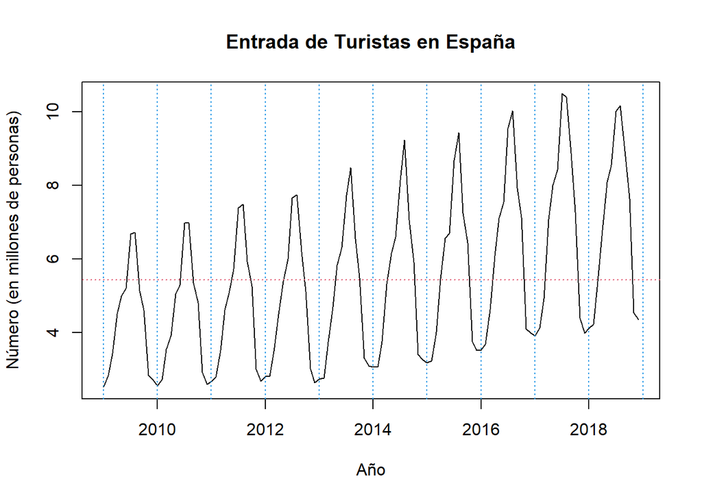

```r
# Plot de la serie
plot(serie, main = "Entrada de Turistas en España", xlab = "Año", ylab = "Número (en millones de personas)")
abline(v = 1990:2020, col = 4, lty = 3)
m <- mean(serie)
abline(h = m, lty = 3, col = 2)
```

**Interpretación**  
El gráfico indica la evolución mensual del número de entrada de turistas (en millones de personas). Las líneas verticales marcan los años principales, mientras que la línea horizontal roja representa el valor promedio de turistas. Vemos que tiene tendencia y ciertos picos y valles que se repiten cada año.

# Parte 3: Estadísticas Básicas de la Serie

Se calcula información descriptiva básica como la longitud, el inicio y fin de la serie, y la frecuencia de las observaciones.

```r
# Características de la serie
serie
```

```
##            Jan       Feb       Mar       Apr       May       Jun       Jul
## 2009  2.517980  2.833450  3.434132  4.511701  4.988169  5.203390  6.678047
## 2010  2.542841  2.723363  3.543400  3.910779  5.045676  5.289108  6.981417
## 2011  2.655823  2.784271  3.510049  4.612689  5.134990  5.734891  7.385628
## 2012  2.811021  2.797620  3.592387  4.495693  5.385212  5.996190  7.654573
## 2013  2.728272  2.756023  3.738846  4.690772  5.823063  6.308842  7.727186
## 2014  3.064668  3.064422  3.760531  5.311830  6.149737  6.590848  8.149091
## 2015  3.175916  3.228369  4.007974  5.454187  6.572839  6.690369  8.678782
## 2016  3.526624  3.678786  4.627065  6.086458  7.110937  7.552826  9.545564
## 2017  3.905841  4.119187  4.914065  7.081335  8.002819  8.432041 10.493503
## 2018  4.106529  4.218107  5.393391  6.780561  8.085771  8.554172 10.020572
##            Aug       Sep       Oct       Nov       Dec
## 2009  6.723277  5.133169  4.607406  2.837367  2.709553
## 2010  6.985291  5.351470  4.806009  2.911187  2.586430
## 2011  7.489515  5.934029  5.257086  3.004607  2.673306
## 2012  7.749332  6.202106  5.123303  3.020767  2.636292
## 2013  8.481924  6.550855  5.481295  3.305272  3.085997
## 2014  9.240208  7.066407  5.907192  3.396167  3.255109
## 2015  9.429632  7.243067  6.432119  3.754706  3.513026
## 2016 10.027722  7.932508  7.137880  4.098316  3.990511
## 2017 10.397222  8.877269  7.269657  4.392364  3.982440
## 2018 10.175348  8.932692  7.649712  4.537058  4.354821
```

```r
length(serie)
```

```
## [1] 120
```

```r
start(serie)
```

```
## [1] 2009    1
```

```r
end(serie)
```

```
## [1] 2018   12
```

```r
frequency(serie)
```

```
## [1] 12
```

**Interpretación**  
Estos datos confirman la estructura temporal de la serie. La frecuencia mensual implica que cada año tiene 12 puntos de observación.

# Parte 4: Clasificación de la serie

```r
summary(serie)
```

```
##        V1
##  Min.   : 2.518
##  1st Qu.: 3.539
##  Median : 5.134
##  Mean   : 5.436
##  3rd Qu.: 7.070
##  Max.   :10.494
```

## 4.1 Varianza

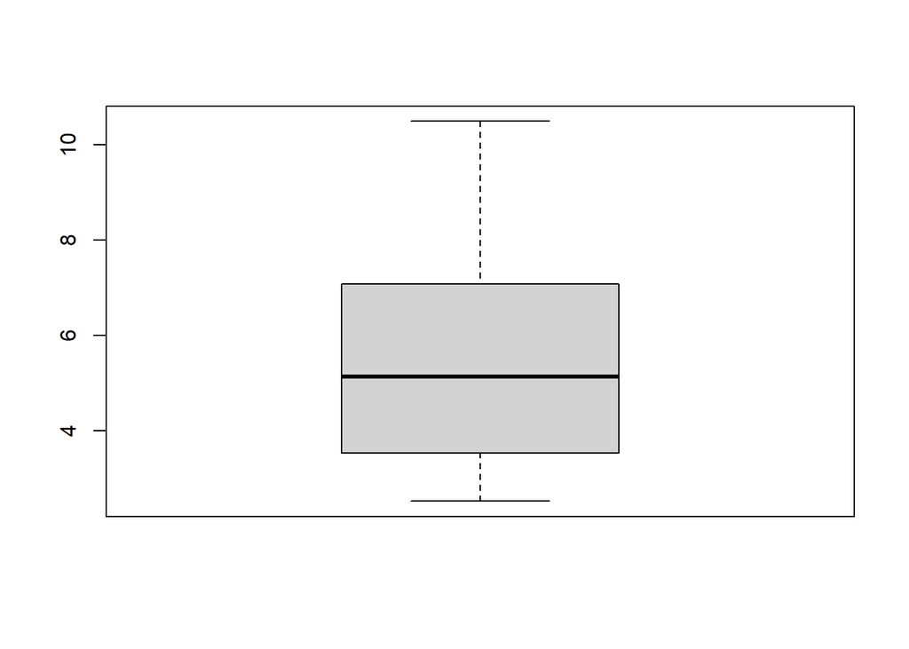

```r
boxplot(serie)
```

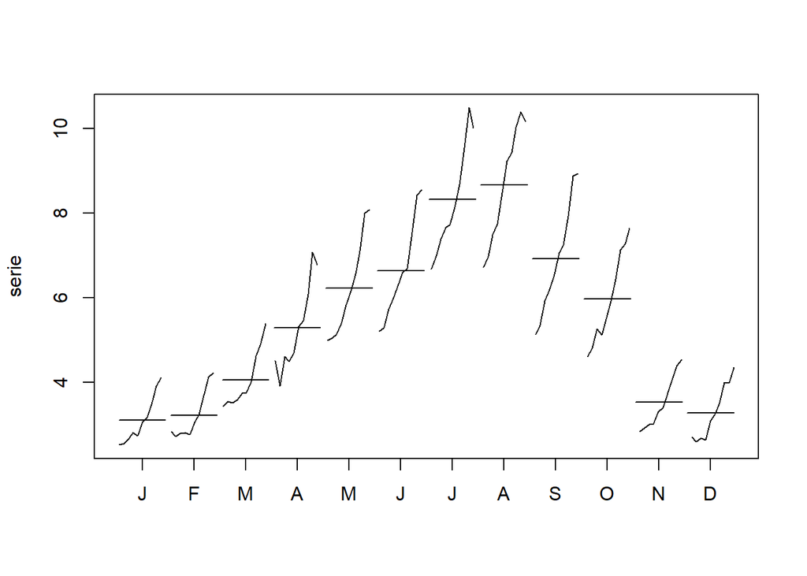

```r
monthplot(serie)
```

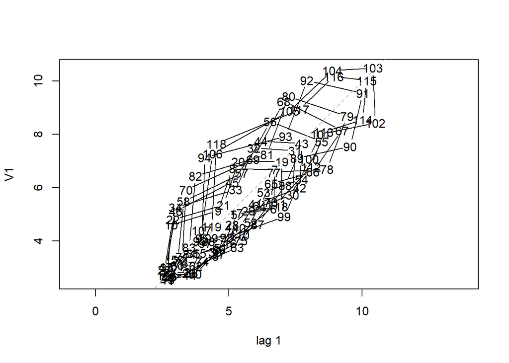

```r
lag.plot(serie)
```

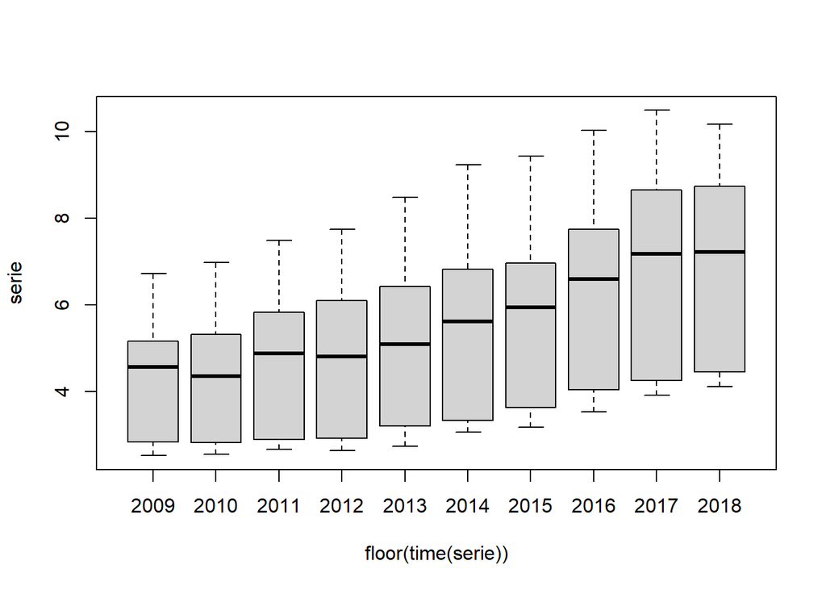

```r
boxplot(serie~floor(time(serie)))
```

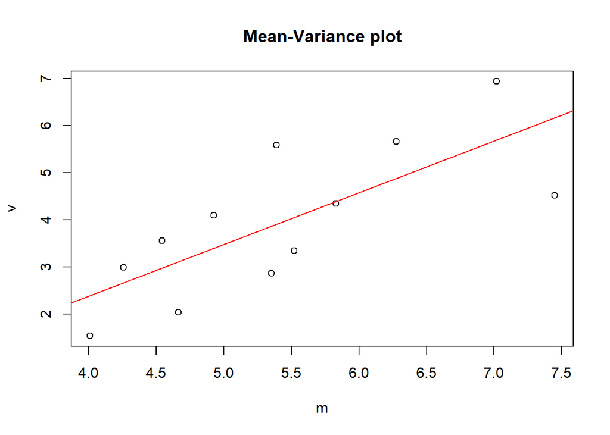

```r
m=apply(matrix(serie,ncol=12),2,mean)
v=apply(matrix(serie,ncol=12),2,var)
plot(v~m,main="Mean-Variance plot")
abline(lm(v~m), col="red")
```

**Observaciones**  
Con el boxplot y el summary, los valores oscilan entre 2.5 y 10.5, esta notable amplitud indica cierta variabilidad en los datos.  
En el monthplot por años vemos que los meses de Julio-Agosto tienen mayor media que los otros meses.  
Tanto en el boxplot por años como en el Mean-Var plot muestra que la varianza de los datos no es constante: a mayor media mayor esperanza.

## 4.2 Descomposición aditiva

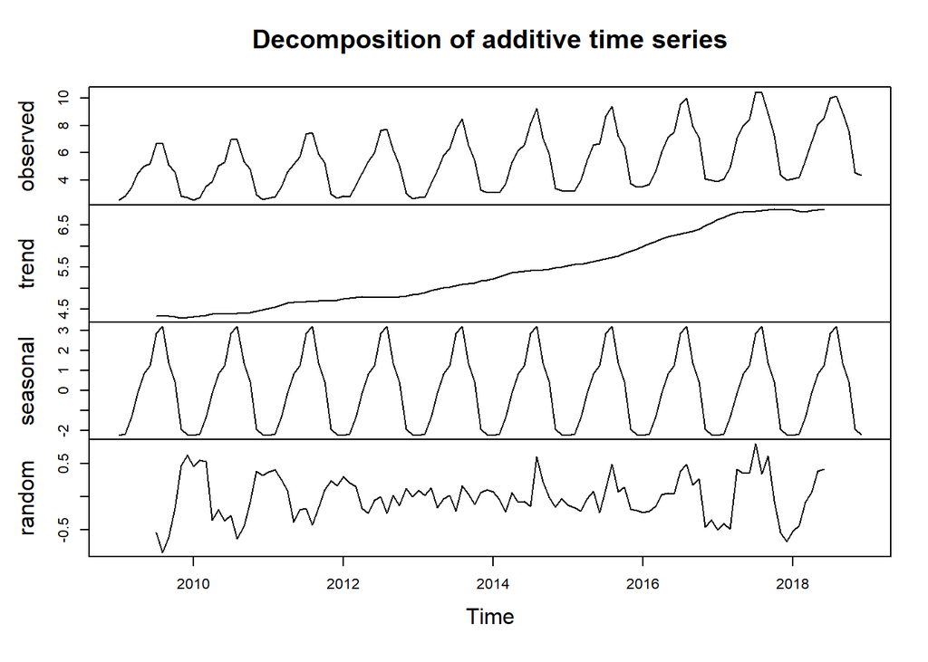

```r
plot(decompose(serie))
```

**Observaciones**  
Es una serie con error aditivo.  
Tiene tendencia (no constante).  
Tiene estacionalidad por un claro patrón repetido cada 12 meses.

**Interpretación**  
Su tendencia es linealmente creciente.  
La estacionalidad es multiplicativa dada la heterocedasiticidad de los datos.  
Esta serie se clasificaría como una de tipo AAM (tipo 6), en siglas ETS.

# Parte 5: Transformación de la serie

Queremos obtener una serie estacionaria aplicandole ciertas transformaciones a la serie original.

## 5.1 Aplicación logarítmica

Dada que la varianza no es constante aplicamos el logaritmo a nuestra serie temporal.

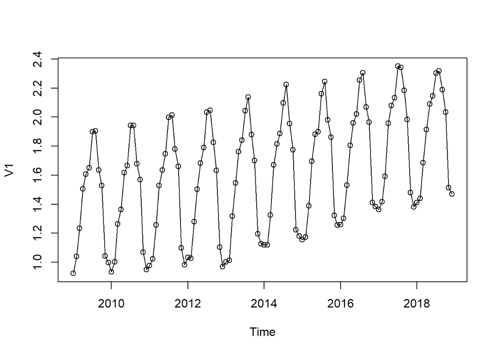

```r
lnserie=log(serie)
plot(lnserie,type="o")
```

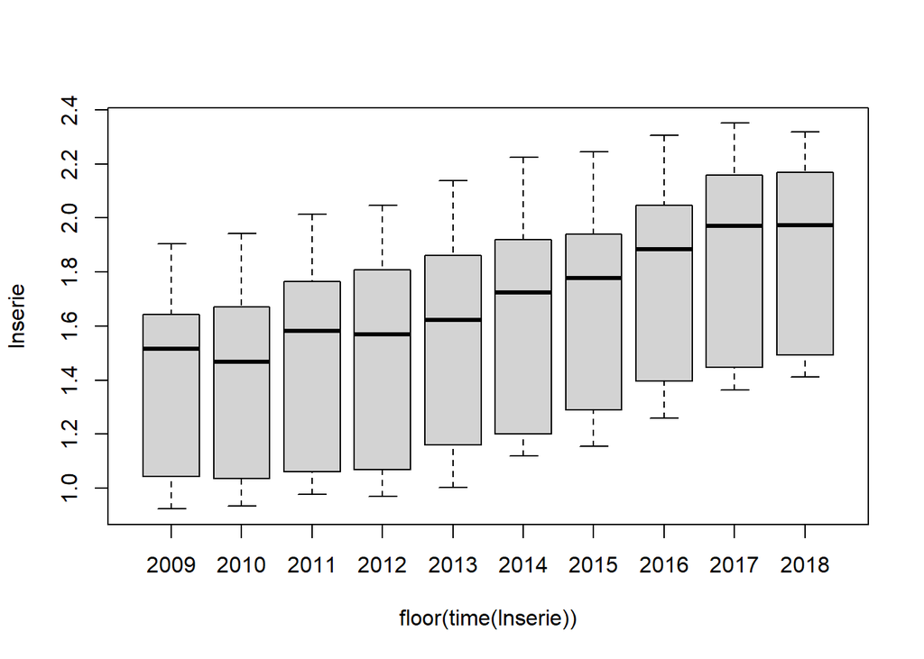

```r
boxplot(lnserie~floor(time(lnserie)))
```

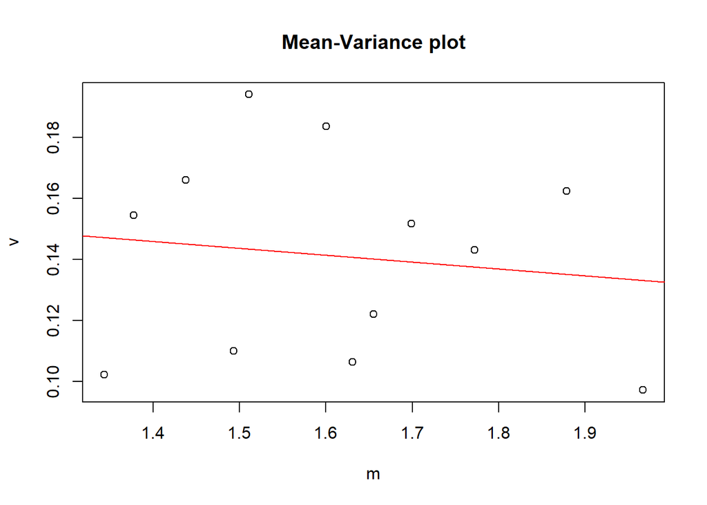

```r
m=apply(matrix(lnserie,ncol=12),2,mean)
v=apply(matrix(lnserie,ncol=12),2,var)
plot(v~m,main="Mean-Variance plot")
abline(lm(v~m), col="red")
```

**Observaciones**  
La dependencia de la varianza en función de la media ha disminuído dado que la recta es casi paralela y los boxplots de tamaño similar.  
Asumimos homocedasticidad.

## 5.2 Estacionalidad

Anteriormente ya hemos visto que hay un patrón repetitivo cada año.  
Por ello aplicamos una diferenciación (D=1) de orden S=12.

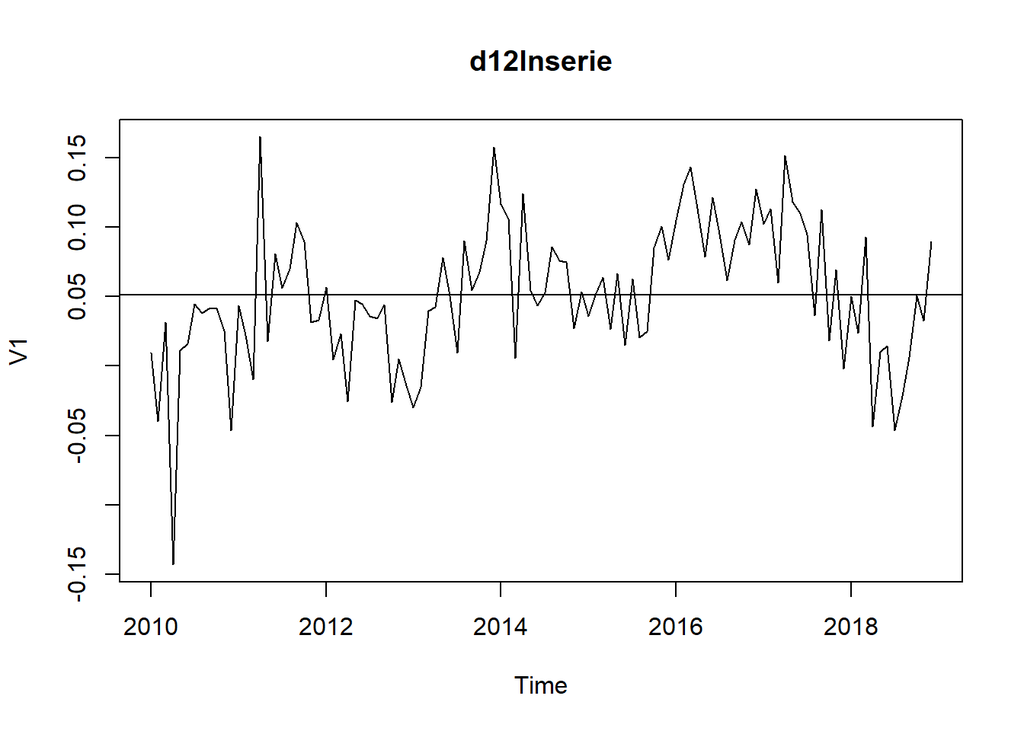

```r
d12lnserie<-diff(lnserie,lag=12)
plot(d12lnserie,main="d12lnserie")
abline(h=mean(d12lnserie))
```

**Observaciones**  
No vemos ningún patrón que se repita, hemos eliminado la componente de estacionalidad.  
Nos presentamos ante el problema de que claramente la media no es constante.

## 5.3 Media constante

Aplicamos diferenciaciones regulares para remover las raíces unitarias.

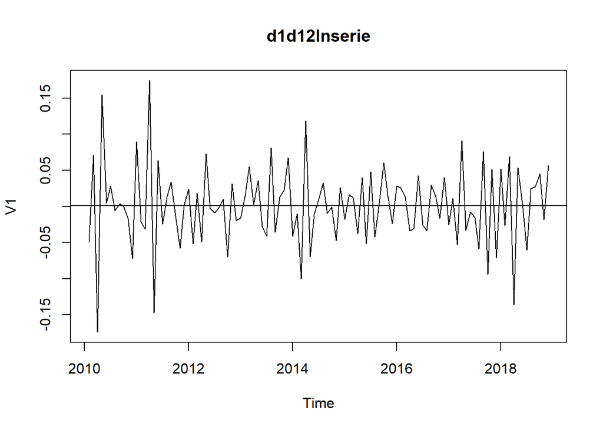

```r
d1d12lnserie<-diff(d12lnserie)
plot(d1d12lnserie,main="d1d12lnserie")
abline(h=mean(d1d12lnserie))
```

```r
mean(d1d12lnserie)
```

```
## [1] 0.0007435873
```

```r
var(lnserie)
```

```
##           V1
## V1 0.1628926
```

```r
var(d12lnserie)
```

```
##             V1
## V1 0.002528717
```

```r
var(d1d12lnserie)
```

```
##             V1
## V1 0.002992208
```

```r
var(diff(d1d12lnserie))
```

```
##             V1
## V1 0.009618332
```

## 5.4 ACF

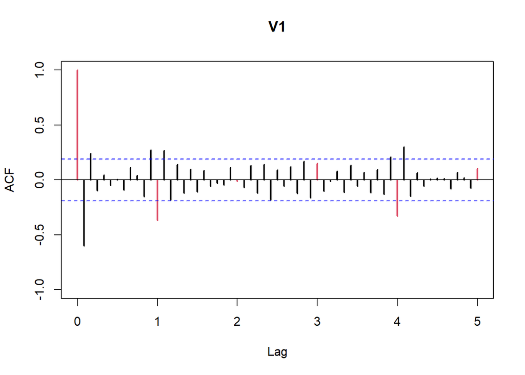

```r
acf(d1d12lnserie,ylim=c(-1,1),lag.max=60,col=c(2,rep(1,11)),lwd=2)
```

**Observaciones**  
La acf decae rápidamente hacia cero.

**Interpretación**  
Tras aplicar el logaritmo, una diferenciación de orden 12 y una diferenciación regular obtenemos al fin una serie estacionaria.  
De momento D=1, S=12, d=1.

# Parte 6: Identificación de plausibles procesos estacionarios

## 6.1 Interpretación de las (P)ACF

Intentaremos dar varios modelos en función de las (P)ACF.

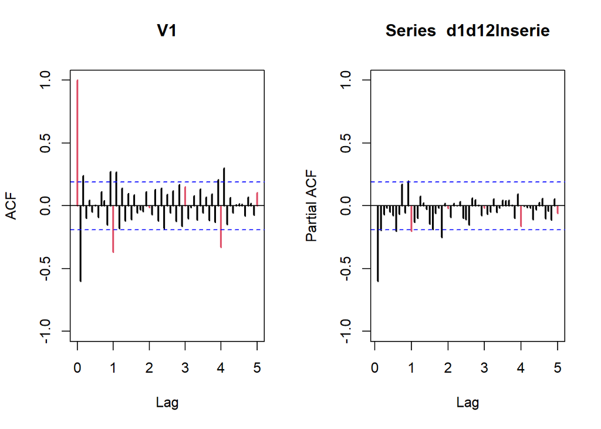

```r
par(mfrow=c(1,2))
acf(d1d12lnserie,ylim=c(-1,1),lag.max=60,col=c(2,rep(1,11)),lwd=2)
pacf(d1d12lnserie,ylim=c(-1,1),lag.max=60,col=c(rep(1,11),2),lwd=2)
```

```r
par(mfrow=c(1,1))
```

**Observaciones**  
Parte regular (en negro): $AR(1), MA(2)$.  
Parte estacional (en rojo): $SAR(1), SMA(1), SMA(4)$.

## 6.2 Modelos propuestos para la serie estacionaria $W_t$

$W_t= (1-B) (1-B^{12})ln(X_t)$; en este caso $mean(W_t)=0$  
**Diferenciaciones aplicadas:** $d=1$ y $D=1$ con $S=12$.

**Modelo 1.** $AR(1)SAR(1)_{12}$ para $W_t$:

$$(1 - \phi_1 B)(1 - \Phi_1 B^{12})W_t = Z_t; Z_t \sim N(0,\sigma^2_z)$$

**Modelo 2.** $AR(1)SMA(1)_{12}$ para $W_t$:

$$(1 - \phi_1 B)W_t = (1 + \Theta_1 B^{12})Z_t; Z_t ~ N(0,\sigma^2_z)$$

**Modelo 3.** $AR(1)SMA(4)_{12}$ para $W_t$:

$$(1 - \phi_1 B)W_t = (1 + \Theta_1 B^{12} + \Theta_2 B^{24} + \Theta_3
B^{36} + \Theta_4 B^{48})Z_t; Z_t ~ N(0,\sigma^2_z)$$

**Modelo 4.** $MA(2)SAR(1)_{12}$ para $W_t$:

$$(1 - \Phi_1 B^{12})W_t = (1 + \theta_1 B + \theta_2 B^{2})Z_t; Z_t \sim
N(0,\sigma^2_z)$$

**Modelo 5.** $MA(2)SMA(1)_{12}$ para $W_t$:

$$W_t = (1 + \theta_1 B + \theta_2 B^{2})(1 + \Theta_1 B^{12})Z_t; Z_t
\sim N(0,\sigma^2_z)$$

**Modelo 6.** $MA(2)SMA(4)_{12}$ para $W_t$:

$$W_t = (1 + \theta_1 B + \theta_2 B^{2})(1 + \Theta_1 B^{12} + \Theta_2
B^{24} + \Theta_3 B^{36} + \Theta_4 B^{48})Z_t; Z_t \sim N(0,\sigma^2_z)$$

## 6.3 Estimación de los modelos identificados

Procederemos de la siguiente manera.  
Estimamos el modelo con la serie estacionaria $W_t$ y miramos su intercepto. Si su intercepto no es significativo, que es equivalente a que el valor absoluto de su T-ratio sea inferior que 2, entonces haremos una nueva estimación del modelo usando la serie no estacionaria $ln(X_t)$.  
También podría ocurrir que algún parámetro del modelo, a parte del intercepto, dé que no es significativo. En el caso de que corresponda al parámetro del mayor grado de alguno de los polinomios característicos, volveremos a estimarlo en un segundo modelo sin él (le bajaremos el grado al polinomio).  
Al i-ésimo modelo con $W_t$ se llamará modiA y con $X_t$ modiB.

### 6.3.1 Estimación Modelo 1

**Ecuación** $AR(1)SAR(1)_{12}$ para $W_t$

```r
(mod1A=arima(d1d12lnserie, order=c(1,0,0),seasonal=list(order=c(1,0,0),period=12)))
```

```
##
## Call:
## arima(x = d1d12lnserie, order = c(1, 0, 0), seasonal = list(order = c(1, 0,
##     0), period = 12))
##
## Coefficients:
##           ar1     sar1  intercept
##       -0.5585  -0.3620     0.0005
## s.e.   0.0818   0.1037     0.0019
##
## sigma^2 estimated as 0.001664:  log likelihood = 189.47,  aic = -370.94
```

```r
cat("Modelo 1A \nT-ratios:",round(mod1A$coef/sqrt(diag(mod1A$var.coef)),2))
```

```
## Modelo 1A
## T-ratios: -6.83 -3.49 0.28
```

```r
(mod1B=arima(lnserie, order=c(1,1,0),seasonal=list(order=c(1,1,0),period=12)))
```

```
##
## Call:
## arima(x = lnserie, order = c(1, 1, 0), seasonal = list(order = c(1, 1, 0), period = 12))
##
## Coefficients:
##           ar1     sar1
##       -0.5581  -0.3622
## s.e.   0.0818   0.1037
##
## sigma^2 estimated as 0.001665:  log likelihood = 189.43,  aic = -372.86
```

```r
cat("Modelo 1B \nT-ratios:",round(mod1B$coef/sqrt(diag(mod1B$var.coef)),2))
```

```
## Modelo 1B
## T-ratios: -6.82 -3.49
```

### 6.3.2 Estimación Modelo 2

**Ecuación** $AR(1)SMA(1)_{12}$ para $W_t$

```r
(mod2A=arima(d1d12lnserie, order=c(1,0,0),seasonal=list(order=c(0,0,1),period=12)))
```

```
##
## Call:
## arima(x = d1d12lnserie, order = c(1, 0, 0), seasonal = list(order = c(0, 0,
##     1), period = 12))
##
## Coefficients:
##           ar1     sma1  intercept
##       -0.5486  -0.4067     0.0006
## s.e.   0.0841   0.1219     0.0016
##
## sigma^2 estimated as 0.001647:  log likelihood = 189.79,  aic = -371.59
```

```r
cat("Modelo 2A \nT-ratios:",round(mod2A$coef/sqrt(diag(mod2A$var.coef)),2))
```

```
## Modelo 2A
## T-ratios: -6.53 -3.34 0.36
```

```r
(mod2B=arima(lnserie, order=c(1,1,0),seasonal=list(order=c(0,1,1),period=12)))
```

```
##
## Call:
## arima(x = lnserie, order = c(1, 1, 0), seasonal = list(order = c(0, 1, 1), period = 12))
##
## Coefficients:
##           ar1     sma1
##       -0.5483  -0.4044
## s.e.   0.0841   0.1212
##
## sigma^2 estimated as 0.001649:  log likelihood = 189.73,  aic = -373.46
```

```r
cat("Modelo 2B \nT-ratios:",round(mod2B$coef/sqrt(diag(mod2B$var.coef)),2))
```

```
## Modelo 2B
## T-ratios: -6.52 -3.34
```

### 6.3.3 Estimación Modelo 3

**Ecuación** $AR(1)SMA(4)_{12}$ para $W_t$

```r
(mod3A=arima(d1d12lnserie, order=c(1,0,0),seasonal=list(order=c(0,0,4),period=12)))
```

```
##
## Call:
## arima(x = d1d12lnserie, order = c(1, 0, 0), seasonal = list(order = c(0, 0,
##     4), period = 12))
##
## Coefficients:
##           ar1     sma1    sma2     sma3     sma4  intercept
##       -0.5391  -0.4630  0.0400  -0.2222  -0.3547     0.0005
## s.e.   0.0834   0.2065  0.1896   0.1836   0.1588     0.0014
##
## sigma^2 estimated as 0.00129:  log likelihood = 194.37,  aic = -374.73
```

```r
cat("Modelo 3A \nT-ratios:",round(mod3A$coef/sqrt(diag(mod3A$var.coef)),2))
```

```
## Modelo 3A
## T-ratios: -6.46 -2.24 0.21 -1.21 -2.23 0.35
```

```r
(mod3B=arima(lnserie, order=c(1,1,0),seasonal=list(order=c(0,1,4),period=12)))
```

```
##
## Call:
## arima(x = lnserie, order = c(1, 1, 0), seasonal = list(order = c(0, 1, 4), period = 12))
##
## Coefficients:
##           ar1     sma1    sma2     sma3     sma4
##       -0.5383  -0.4614  0.0424  -0.2230  -0.3578
## s.e.   0.0834   0.2077  0.1906   0.1851   0.1595
##
## sigma^2 estimated as 0.00129:  log likelihood = 194.31,  aic = -376.61
```

```r
cat("Modelo 3B \nT-ratios:",round(mod3B$coef/sqrt(diag(mod3B$var.coef)),2))
```

```
## Modelo 3B
## T-ratios: -6.45 -2.22 0.22 -1.2 -2.24
```

### 6.3.4 Estimación Modelo 4

**Ecuación** $MA(2)SAR(1)_{12}$ para $W_t$

```r
(mod4A=arima(d1d12lnserie, order=c(0,0,2),seasonal=list(order=c(1,0,0),period=12)))
```

```
##
## Call:
## arima(x = d1d12lnserie, order = c(0, 0, 2), seasonal = list(order = c(1, 0,
##     0), period = 12))
##
## Coefficients:
##           ma1     ma2     sar1  intercept
##       -0.6856  0.1298  -0.3930     0.0005
## s.e.   0.0923  0.1279   0.1018     0.0013
##
## sigma^2 estimated as 0.00157:  log likelihood = 192.37,  aic = -374.74
```

```r
cat("Modelo 4A \nT-ratios:",round(mod4A$coef/sqrt(diag(mod4A$var.coef)),2))
```

```
## Modelo 4A
## T-ratios: -7.43 1.02 -3.86 0.38
```

```r
(mod4B=arima(lnserie, order=c(0,1,1),seasonal=list(order=c(1,1,0),period=12)))
```

```
##
## Call:
## arima(x = lnserie, order = c(0, 1, 1), seasonal = list(order = c(1, 1, 0), period = 12))
##
## Coefficients:
##           ma1     sar1
##       -0.6542  -0.4108
## s.e.   0.0801   0.1000
##
## sigma^2 estimated as 0.001585:  log likelihood = 191.71,  aic = -377.42
```

```r
cat("Modelo 4B \nT-ratios:",round(mod4B$coef/sqrt(diag(mod4B$var.coef)),2))
```

```
## Modelo 4B
## T-ratios: -8.17 -4.11
```

### 6.3.5 Estimación Modelo 5

**Ecuación** $MA(2)SMA(1)_{12}$ para $W_t$

```r
(mod5A=arima(d1d12lnserie, order=c(0,0,2),seasonal=list(order=c(0,0,1),period=12)))
```

```
##
## Call:
## arima(x = d1d12lnserie, order = c(0, 0, 2), seasonal = list(order = c(0, 0,
##     1), period = 12))
##
## Coefficients:
##           ma1     ma2     sma1  intercept
##       -0.6665  0.0995  -0.4131     0.0005
## s.e.   0.0964  0.1325   0.1251     0.0011
##
## sigma^2 estimated as 0.001575:  log likelihood = 192.07,  aic = -374.15
```

```r
cat("Modelo 5A \nT-ratios:",round(mod5A$coef/sqrt(diag(mod5A$var.coef)),2))
```

```
## Modelo 5A
## T-ratios: -6.91 0.75 -3.3 0.51
```

```r
(mod5B=arima(lnserie, order=c(0,1,1),seasonal=list(order=c(0,1,1),period=12)))
```

```
##
## Call:
## arima(x = lnserie, order = c(0, 1, 1), seasonal = list(order = c(0, 1, 1), period = 12))
##
## Coefficients:
##           ma1     sma1
##       -0.6442  -0.4390
## s.e.   0.0854   0.1215
##
## sigma^2 estimated as 0.001583:  log likelihood = 191.6,  aic = -377.2
```

```r
cat("Modelo 5B \nT-ratios:",round(mod5B$coef/sqrt(diag(mod5B$var.coef)),2))
```

```
## Modelo 5B
## T-ratios: -7.54 -3.61
```

### 6.3.6 Estimación Modelo 6

**Ecuación** $MA(2)SMA(4)_{12}$ para $W_t$

```r
(mod6A=arima(d1d12lnserie, order=c(0,0,2),seasonal=list(order=c(0,0,4),period=12)))
```

```
##
## Call:
## arima(x = d1d12lnserie, order = c(0, 0, 2), seasonal = list(order = c(0, 0,
##     4), period = 12))
##
## Coefficients:
##           ma1     ma2     sma1    sma2     sma3     sma4  intercept
##       -0.6957  0.0733  -0.5056  0.1643  -0.3207  -0.3380      4e-04
## s.e.   0.0933  0.1083   0.1810  0.1903   0.1998   0.1684      8e-04
##
## sigma^2 estimated as 0.001168:  log likelihood = 198.31,  aic = -380.61
```

```r
cat("Modelo 6A \nT-ratios:",round(mod6A$coef/sqrt(diag(mod6A$var.coef)),2))
```

```
## Modelo 6A
## T-ratios: -7.46 0.68 -2.79 0.86 -1.61 -2.01 0.57
```

```r
(mod6B=arima(lnserie, order=c(0,1,1),seasonal=list(order=c(0,1,4),period=12)))
```

```
##
## Call:
## arima(x = lnserie, order = c(0, 1, 1), seasonal = list(order = c(0, 1, 4), period = 12))
##
## Coefficients:
##           ma1     sma1    sma2     sma3     sma4
##       -0.6638  -0.5171  0.1805  -0.3242  -0.3392
## s.e.   0.0786   0.1818  0.2013   0.2163   0.1751
##
## sigma^2 estimated as 0.001173:  log likelihood = 197.91,  aic = -383.81
```

```r
cat("Modelo 6B \nT-ratios:",round(mod6B$coef/sqrt(diag(mod6B$var.coef)),2))
```

```
## Modelo 6B
## T-ratios: -8.45 -2.84 0.9 -1.5 -1.94
```

# Parte 7: Validación de los modelos

De momento el que parece ser el mejor modelo según el AIC es el modelo 6B.  
Cómo los B modelos son mejores que los A, realizaremos la validación sólo de éstos.  
Para la validación usaremos la siguiente función.

```r
#################Validation#################################
validation=function(model){
 s=frequency(get(model$series))
  resid=model$residuals
  par(mfrow=c(2,2),mar=c(3,3,3,3))
  #Residuals plot
  plot(resid,main="Residuals")
  abline(h=0)
  abline(h=c(-3*sd(resid),3*sd(resid)),lty=3,col=4)
  #Square Root of absolute values of residuals (Homocedasticity)
  scatter.smooth(sqrt(abs(resid)),main="Square Root of Absolute residuals",
                 lpars=list(col=2))

  #Normal plot of residuals
  qqnorm(resid)
  qqline(resid,col=2,lwd=2)

  ##Histogram of residuals with normal curve
  hist(resid,breaks=20,freq=FALSE)
  curve(dnorm(x,mean=mean(resid),sd=sd(resid)),col=2,add=T)


  #ACF & PACF of residuals
  par(mfrow=c(1,2))
  acf(resid,ylim=c(-1,1),lag.max=60,col=c(2,rep(1,s-1)),lwd=1)
  pacf(resid,ylim=c(-1,1),lag.max=60,col=c(rep(1,s-1),2),lwd=1)
  par(mfrow=c(1,1))

  #ACF & PACF of square residuals
  par(mfrow=c(1,2))
  acf(resid^2,ylim=c(-1,1),lag.max=60,col=c(2,rep(1,s-1)),lwd=1)
  pacf(resid^2,ylim=c(-1,1),lag.max=60,col=c(rep(1,s-1),2),lwd=1)
  par(mfrow=c(1,1))

  #Ljung-Box p-values
  par(mar=c(2,2,1,1))
  tsdiag(model,gof.lag=7*s)
  cat("\n--------------------------------------------------------------------\n")
  print(model)

  #Stationary and Invertible
  cat("\nModul of AR Characteristic polynomial Roots: ",
      Mod(polyroot(c(1,-model$model$phi))),"\n")
  cat("\nModul of MA Characteristic polynomial Roots: ",
      Mod(polyroot(c(1,model$model$theta))),"\n")

  #Model expressed as an MA infinity (psi-weights)
  psis=ARMAtoMA(ar=model$model$phi,ma=model$model$theta,lag.max=36)
  names(psis)=paste("psi",1:36)
  cat("\nPsi-weights (MA(inf))\n")
  cat("\n--------------------\n")
  print(psis[1:20])
#extra
  plot(psis,type="h",main="Pesos Psis - MA infinito")

  #Model expressed as an AR infinity (pi-weights)
  pis=-ARMAtoMA(ar=-model$model$theta,ma=-model$model$phi,lag.max=36)
  names(pis)=paste("pi",1:36)
  cat("\nPi-weights (AR(inf))\n")
  cat("\n--------------------\n")
  print(pis[1:20])
#extra
  plot(pis,type="h",main="Pesos Pis - AR infinito")


  ## Add here complementary tests (use with caution!)
  ##---------------------------------------------------------
  cat("\nNormality Tests\n")
  cat("\n--------------------\n")

  ##Shapiro-Wilks Normality test
  print(shapiro.test(resid(model)))
  sw<-round(shapiro.test(resid(model))$p.value,4)
  suppressMessages(require(nortest,quietly=TRUE,warn.conflicts=FALSE))
  ##Anderson-Darling test
  print(ad.test(resid(model)))
  ad<-round(ad.test(resid(model))$p.value,4)

  suppressMessages(require(tseries,quietly=TRUE,warn.conflicts=FALSE))
  ##Jarque-Bera test
  print(jarque.bera.test(resid(model)))
  jb<-round(jarque.bera.test(resid(model))$p.value,4)

  cat("\nHomoscedasticity Test\n")
  cat("\n--------------------\n")
  suppressMessages(require(lmtest,quietly=TRUE,warn.conflicts=FALSE))
  ##Breusch-Pagan test
  obs=get(model$series)
  print(bptest(resid(model)~I(obs-resid(model))))
  bp<-round(bptest(resid(model)~I(obs-resid(model)))$p.value,4)

  cat("\nIndependence Tests")
  cat("\n--------------------\n")
  ##Durbin-Watson test
  print(dwtest(resid(model)~I(1:length(resid(model)))))
  dw<-dwtest(resid(model)~I(1:length(resid(model))))$p.value

  ##Ljung-Box test
  cat("\nLjung-Box test\n")
  print(t(apply(matrix(c(1:4,(1:4)*s)),1,function(el) {
    te=Box.test(resid(model),type="Ljung-Box",lag=el)
    c(lag=(te$parameter),statistic=te$statistic[[1]],p.value=te$p.value)})))
  ##************End of complementary tests******************************************
  lj<-round(t(apply(matrix(c(1:4,(1:4)*s)),1,function(el) {
    te=Box.test(resid(model),type="Ljung-Box",lag=el)
    c(lag=(te$parameter),statistic=te$statistic[[1]],p.value=te$p.value)}))[,3],4)

################# Fi Validación ('Validation') #################################

## Resumen de resultados de validación y de adecuación

resumen<-data.frame(Pruebas=1:18)
colnames(resumen)<-paste0("mod1B")
rownames(resumen)<-c("Shapiro-Wilks Normality p-value","Anderson-Darling p-value","Jarque-Bera p-value","Breusch-Pagan p-value","Durbin-Watson p-value",
         "Ljung-Box (lag 1) p-value","Ljung-Box (lag 2) p-value","Ljung-Box (lag 3) p-value","Ljung-Box (lag4) p-value",
         "Ljung-Box (lag 12) p-value","Ljung-Box (lag 24) p-value","Ljung-Box (lag 36) p-value","Ljung-Box (lag 48) p-value",
         "Log Likelihood","AIC","RMSPE", "MAPE","Mean Length")

  resumen[1,1]=sw[1]
  resumen[2,1]=ad[1]
  resumen[3,1]=jb[1]
  resumen[4,1]=bp[1]
  resumen[5,1]=dw[1]
  resumen[6,1]=lj[1]
  resumen[7,1]=lj[2]
  resumen[8,1]=lj[3]
  resumen[9,1]=lj[4]
  resumen[10,1]=lj[5]
  resumen[11,1]=lj[6]
  resumen[12,1]=lj[7]
  resumen[13,1]=lj[8]
  resumen[14,1]=model$loglik
  resumen[15,1]=model$aic
  resumen[16,1]=NA
  resumen[17,1]=NA
  resumen[18,1]=NA
  return(resumen)

}
```

## 7.1 Validación modelo 1B

**Ecuación** $ARIMA(1,1,0)(1,1,0)_{12}$:

$$(1 - \phi_1 B)(1 - \Phi_1 B^{12})(1 - B)(1 - B^{12})ln(X_t) = Z_t; Z_t
\sim N(0,0.001665)$$

con

$$\phi_1 = -0.5581$$
$$\Phi_1 = -0.3622$$

```r
val1 <- validation(mod1B)
```

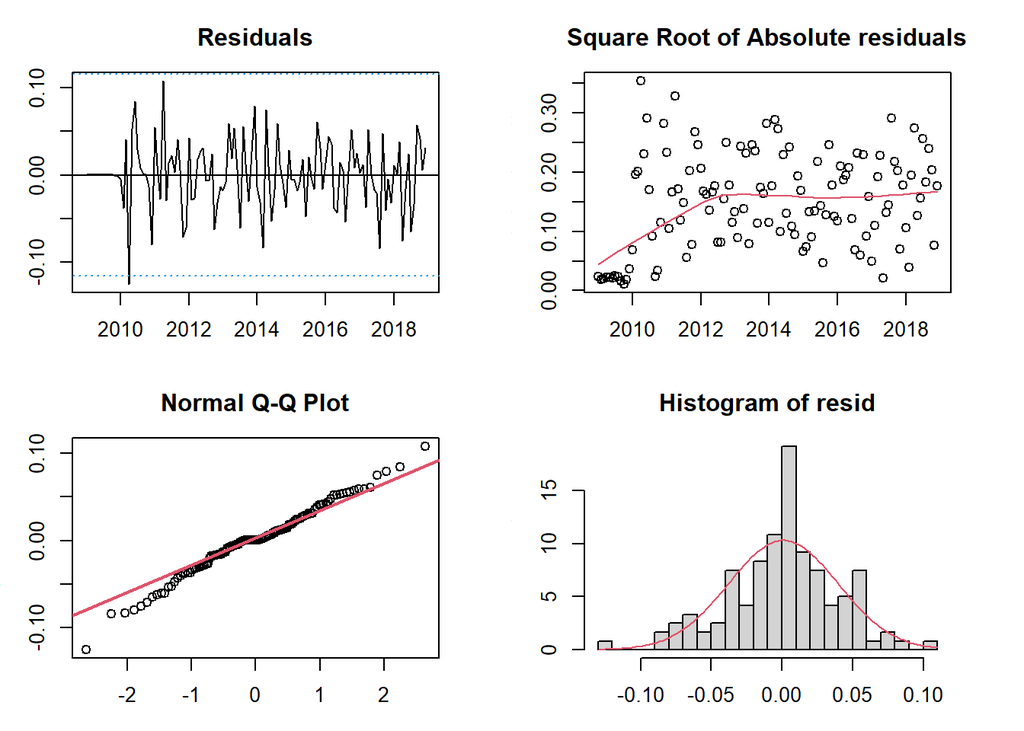

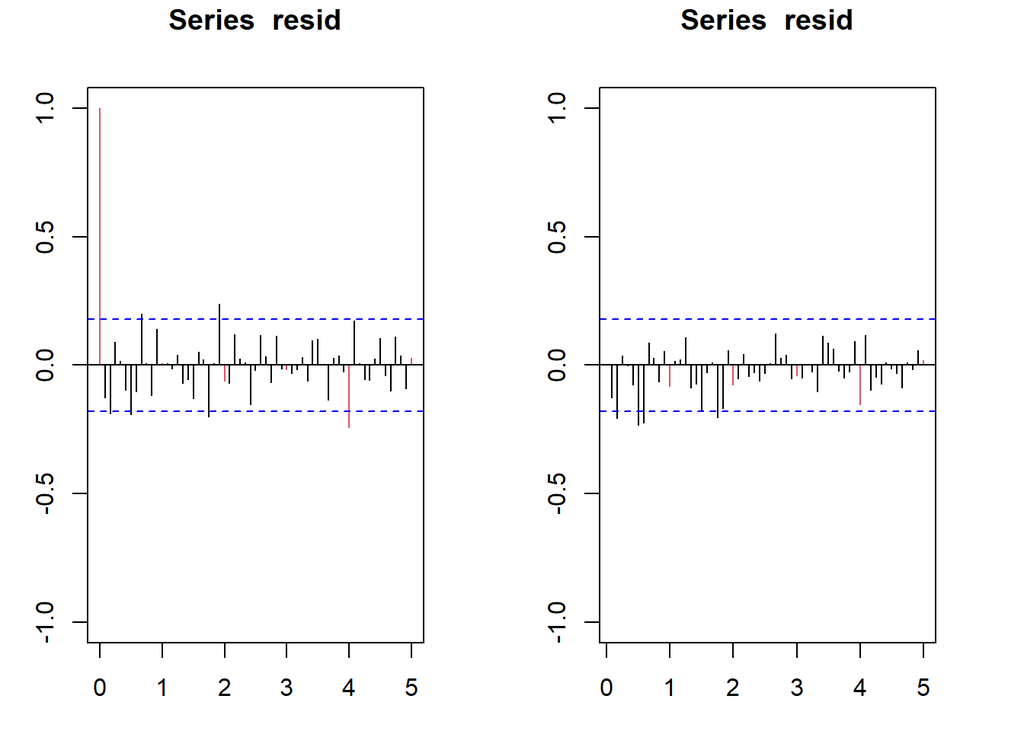

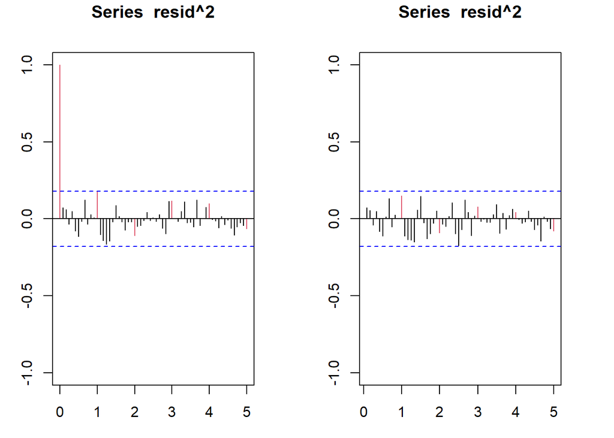

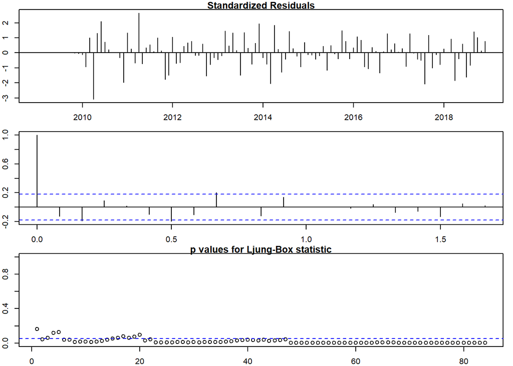